# CDS: Practicing Functions with Gapminder

Luke Ring

31 October, 2022

This is the assignment for Cultural Data Science, Week 43. Assignment 6.

# Assignment

Use the gapminder dataset from Week 43 to produce solutions to the three tasks below.

## Task 1: Defensive GDP Function

> Define a defensive function that calculates the Gross Domestic Product of a nation from the data available in the gapminder dataset. You can use the population and GDPpercapita columns for it. Using that function, calculate the GDP of Denmark in the following years: 1967, 1977, 1987, 1997, 2007, and 2017.

First we define the function:

```r
# simple function to test if a value is interger-like
is_wholenumber <- function(x) {
    if (is.numeric(x) & x %% 1 == 0) {
        return(TRUE)
    } else {
        return(FALSE)
    }
}

# The main GDP calculation function
gapminder_gdp <- function(for_country, for_year) {
    # first check that country is a character
    if (!is.character(for_country)) {
        stop("country must be a character")
    }

    # then check that year is an integer
    if (!is_wholenumber(for_year)) {
        stop("year must be an integer")
    }

    # ensure dplyr is loaded
    if (!require(dplyr)) {
        stop(paste(
            "dplyr is required to run this function.",
            "Please install it with",
            "install.packages('dplyr')"
        ))
    }

    # make sure the gampnider dataset exists
    if (!require(gapminder)) {
        stop(paste(
            "Gapminder package not available,",
            "you can install by running",
            'install.packages("gapminder")'
        ))
    }

    # make the country and gapminder countries lowercase
    # to avoid case sensitivity issues
    country_orig <- for_country
    for_country <- tolower(for_country)
    levels(gapminder$country) <- tolower(levels(gapminder$country))

    # check that the country is in the gapminder dataset
    if (!for_country %in% gapminder$country) {
        stop(paste(
            "Country",
            country_orig,
            "not found in gapminder dataset,",
            "please check the spelling of the country"
        ))
    }

    # check that the year is in the gapminder dataset
    if (!for_year %in% gapminder[gapminder$country == for_country, ]$year) {
        # we can report available range of years for the country
        # to help the user
        years <- gapminder %>%
            filter(country == for_country) %>%
            pull(year)
        stop(paste(
            "Year",
            for_year,
            "not found in gapminder dataset for",
            paste0(country_orig, "."),
            "\nPlease ensure the year is between",
            min(years), "and", paste0(max(years), ".")
        ))
    }

    # calculate the GDP
    gdp <- gapminder %>%
        filter(country == for_country, year == for_year) %>%
        mutate(gdp = pop * gdpPercap) %>%
        pull(gdp)

    # return the GDP
    return(gdp)
}
```

Now we can test the function output for the years requested:

```r
# test the function
test_country <- "Denmark"
test_years <- c(1967, 1977, 1987, 1997, 2007, 2017)

# loop through the years and print the results
for (test_year in test_years) {
    # get the GDP for the country and year
    tryCatch({
        gdp <- gapminder_gdp(test_country, test_year)
        # print the results
        print(paste(
            "The GDP of",
            test_country,
            "in",
            test_year,
            "was",
            scales::label_dollar(prefix = "US$")(gdp)
        ))
    }, error = function(e) {
        # print the error message
        print(e)
    })
}
```

```
## [1] "The GDP of Denmark in 1967 was US$77,116,977,700"
## [1] "The GDP of Denmark in 1977 was US$103,920,280,028"
## [1] "The GDP of Denmark in 1987 was US$128,771,236,166"
## [1] "The GDP of Denmark in 1997 was US$157,476,118,456"
## [1] "The GDP of Denmark in 2007 was US$192,906,627,081"
## <simpleError in gapminder_gdp(test_country, test_year): Year 2017 not found in gapminder dataset for Denmark.
## Please ensure the year is between 1952 and 2007.>
```

We can see that the output shows the GDP for all the years except for 2017, which is not in the dataset. In this case an error is thrown which stops execution. This means you can’t accidentally get strange results from the function, or if you try to do something that isn’t possible, it will not just silently continue, but will let you know immediately, allowing you to fix the issue.

In the test examples above, we have a `try / catch` block which allows us to continue our script / Rmd knitting even if there is an error, this is fine for testing but you would not want to do that with real data unless you are absolutely sure that you don’t care about data that couldn’t be found.

## Task 2: Life Expectancy for countries starting with “B”

> Write a script that loops over each country in the gapminder dataset, tests whether the country starts with a ‘B’ , and prints out whether the life expectancy is smaller than 50, between 50 and 70, or greater than 70. (Hint: remember the grepl function, and review the Control Flow tutorial)

```r
# loop through the countries
for (cntry in unique(gapminder$country)) {
    # test if the country starts with a B
    if (!grepl("^B", cntry)) {
        # if not, skip to the next country
        next
    }

    # get the life expectancy
    life_expectancy <- gapminder %>%
        filter(country == cntry) %>%
        pull(lifeExp)

    # calculate the mean life expectancy for the years found
    mean_life_expectancy <- mean(life_expectancy, na.rm = TRUE)

    # get the range of years
    years <- gapminder %>%
        filter(country == cntry) %>%
        pull(year)

    # print the results
    print(paste(
        "The mean life expectancy for",
        cntry,
        "from",
        min(years), "to", max(years),
        "was: "
    ))

    # test the life expectancy
    if (mean_life_expectancy < 50) {
        print(paste("less than 50 years"))
    } else if (mean_life_expectancy >= 50 & mean_life_expectancy <= 70) {
        print(paste("between 50 and 70 years"))
    } else {
        print(paste("greater than 70 years"))
    }
}
```

```
## [1] "The mean life expectancy for Bahrain from 1952 to 2007 was: "
## [1] "between 50 and 70 years"
## [1] "The mean life expectancy for Bangladesh from 1952 to 2007 was: "
## [1] "less than 50 years"
## [1] "The mean life expectancy for Belgium from 1952 to 2007 was: "
## [1] "greater than 70 years"
## [1] "The mean life expectancy for Benin from 1952 to 2007 was: "
## [1] "less than 50 years"
## [1] "The mean life expectancy for Bolivia from 1952 to 2007 was: "
## [1] "between 50 and 70 years"
## [1] "The mean life expectancy for Bosnia and Herzegovina from 1952 to 2007 was: "
## [1] "between 50 and 70 years"
## [1] "The mean life expectancy for Botswana from 1952 to 2007 was: "
## [1] "between 50 and 70 years"
## [1] "The mean life expectancy for Brazil from 1952 to 2007 was: "
## [1] "between 50 and 70 years"
## [1] "The mean life expectancy for Bulgaria from 1952 to 2007 was: "
## [1] "between 50 and 70 years"
## [1] "The mean life expectancy for Burkina Faso from 1952 to 2007 was: "
## [1] "less than 50 years"
## [1] "The mean life expectancy for Burundi from 1952 to 2007 was: "
## [1] "less than 50 years"
```

### Bonus: the same, but using `tidyverse`

```r
# find countries starting with B, and get the mean life expectancy
gapminder %>%
    filter(grepl("^B", country)) %>%
    group_by(country) %>%
    summarise(
        mean_life_expectancy = mean(lifeExp, na.rm = TRUE),
        years = paste0(min(year), "-", max(year))
    ) %>%
    mutate(
        life_expectancy = case_when(
            mean_life_expectancy < 50 ~ "less than 50 years",
            mean_life_expectancy >= 50 &
                mean_life_expectancy <= 70 ~ "between 50 and 70 years",
            TRUE ~ "greater than 70 years"
        )
    ) %>%
    select(country, years, life_expectancy) %>%
    print(n = Inf)
```

```
## # A tibble: 11 × 3
##    country                years     life_expectancy
##    <fct>                  <chr>     <chr>
##  1 Bahrain                1952-2007 between 50 and 70 years
##  2 Bangladesh             1952-2007 less than 50 years
##  3 Belgium                1952-2007 greater than 70 years
##  4 Benin                  1952-2007 less than 50 years
##  5 Bolivia                1952-2007 between 50 and 70 years
##  6 Bosnia and Herzegovina 1952-2007 between 50 and 70 years
##  7 Botswana               1952-2007 between 50 and 70 years
##  8 Brazil                 1952-2007 between 50 and 70 years
##  9 Bulgaria               1952-2007 between 50 and 70 years
## 10 Burkina Faso           1952-2007 less than 50 years
## 11 Burundi                1952-2007 less than 50 years
```

## Task 3: Plot `life expectancy/time` for countries starting with “M”

> Challenge/Optional: Write a script that loops over each country in the gapminder dataset, tests whether the country starts with a ‘M’ and graphs life expectancy against time (using plot() function) as a line graph if the mean life expectancy is under 50 years.

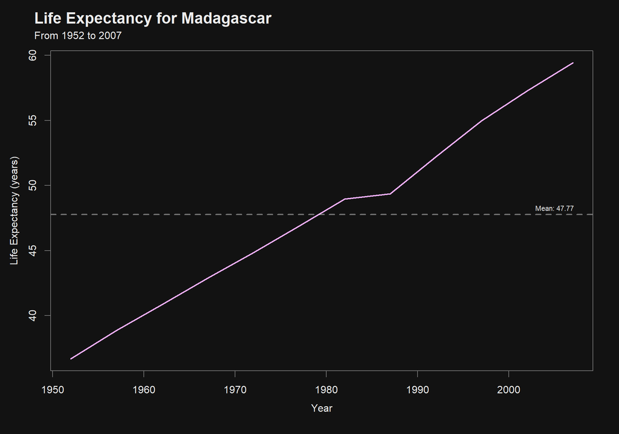

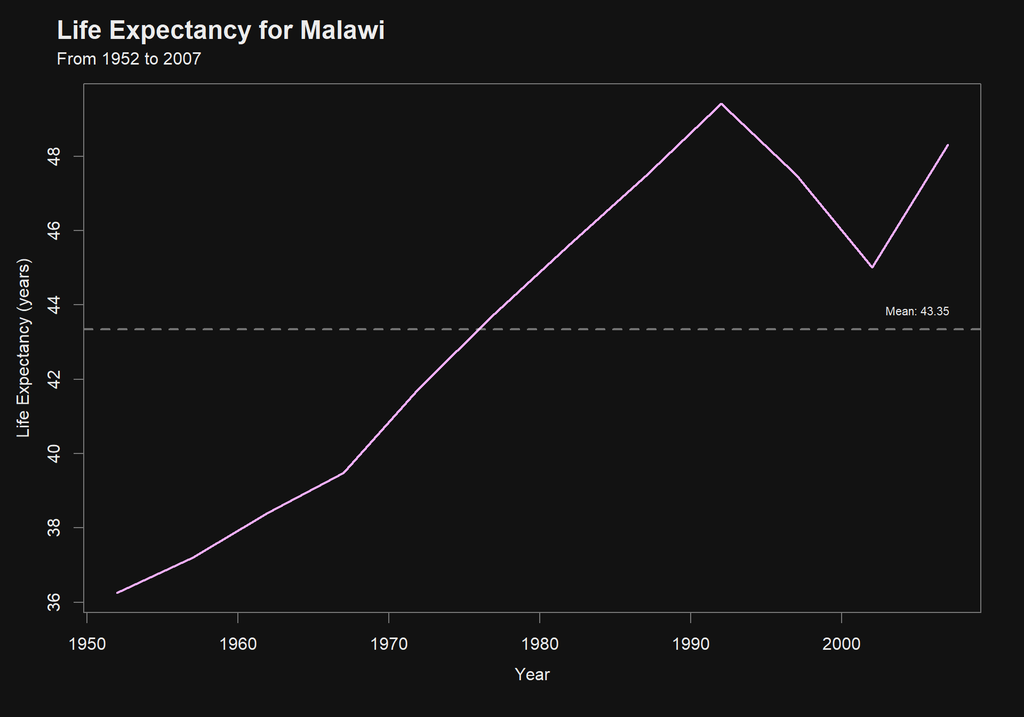

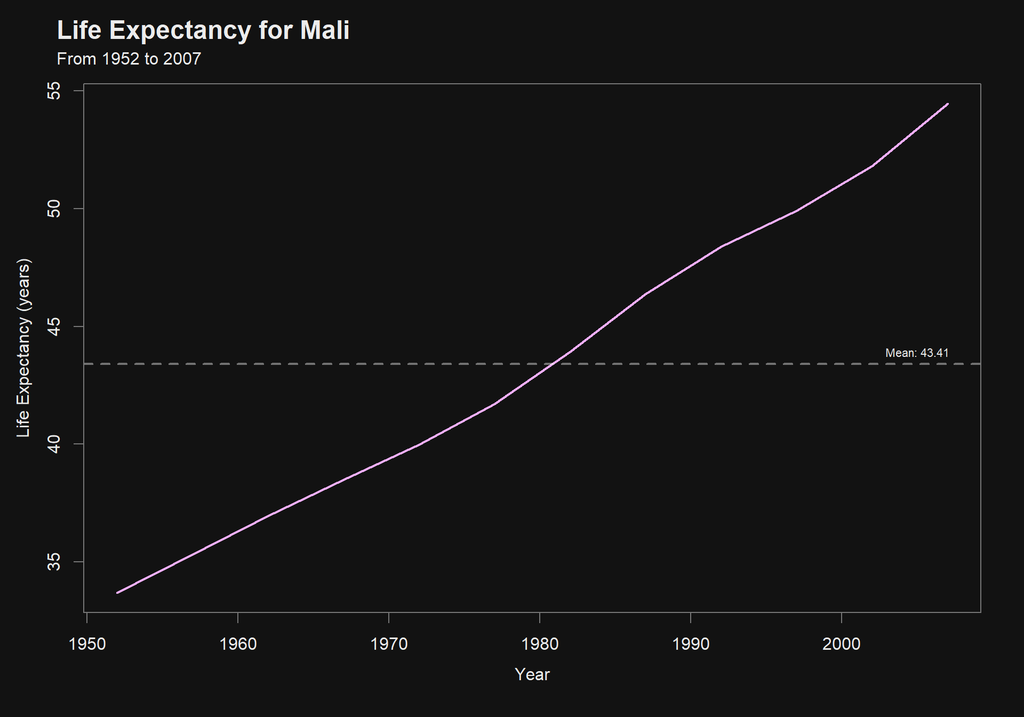

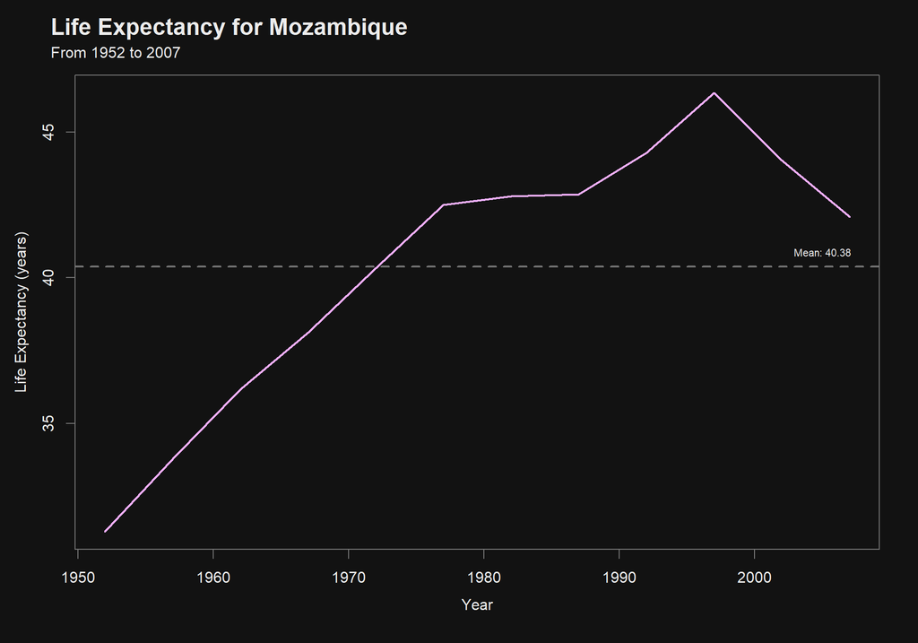

```r
# loop through the countries
for (cntry in unique(gapminder$country)) {
    # test if the country starts with a M
    if (!grepl("^M", cntry)) {
        # if not, skip to the next country
        next
    }

    # get the life expectancy
    life_expectancy <- gapminder %>%
        filter(country == cntry) %>%
        pull(lifeExp)

    # calculate the mean life expectancy for the years found
    mean_life_expectancy <- mean(life_expectancy, na.rm = TRUE)

    # test the life expectancy
    if (mean_life_expectancy < 50) {
        # get the range of years
        years <- gapminder %>%
            filter(country == cntry) %>%
            pull(year)
        # plot the life expectancy and make it look nice
        par(bg = "#121212")
        plot(
            years,
            life_expectancy,
            type = "l", # line plot
            col = "#f0afff", # line color
            lwd = 2, # line width
            cex = 1.2, # label size multiplier
            xlab = "",
            ylab = "",
            axes = FALSE,
            ann = FALSE,
            oma = c(2, 3, 5, 2) # outer margins, b, l, t, r
        )
        # add title
        mtext(
            side = 3,
            line = 2,
            at = min(years) - 4,
            adj = 0,
            cex = 1.5,
            col = "#ececec",
            paste("Life Expectancy for", cntry),
            font = 2 # bold the title
        )
        # add subtitle
        mtext(side = 3,
            line = 0.75,
            at = min(years) - 4,
            adj = 0,
            cex = 1,
            col = "#ececec",
            paste("From", min(years), "to", max(years)))
        # add the axis labels
        title(
            xlab = "Year",
            ylab = "Life Expectancy (years)",
            col.lab = "#ececec",
            mgp = c(2.5, 0.5, 0)
        )
        # add mean line
        abline(h = mean_life_expectancy, col = "#ffffff67", lwd = 2, lty = 2)
        # add mean life expectancy line label
        text(
            x = max(years) - 2,
            y = mean_life_expectancy + 0.5,
            labels = paste(
                "Mean:",
                round(mean_life_expectancy, 2)),
            cex = 0.7,
            col = "#ececec"
        )
        box(col = "#767676")
        axis(1, col = "#767676", col.axis = "#ececec")
        axis(2, col = "#767676", col.axis = "#ececec")
    }
}
```

### Bonus: Similar, but using `tidyverse` and `ggplot2`

```r
# find countries starting with M, and mean life expectancy under 50
m_countries <- gapminder %>%
    filter(grepl("^M", country)) %>%
    group_by(country) %>%
    summarise(
        mean_life_expectancy = mean(lifeExp, na.rm = TRUE),
        years = paste0(min(year), "-", max(year)),
        year_min = min(year),
        year_max = max(year)
    ) %>%
    filter(mean_life_expectancy < 50) %>%
    select(country, years, mean_life_expectancy, year_min, year_max)

# print the countries found and their mean life expectancy
print(m_countries, n = Inf)
```

```
## # A tibble: 4 × 5
##   country    years     mean_life_expectancy year_min year_max
##   <fct>      <chr>                    <dbl>    <int>    <int>
## 1 Madagascar 1952-2007                 47.8     1952     2007
## 2 Malawi     1952-2007                 43.4     1952     2007
## 3 Mali       1952-2007                 43.4     1952     2007
## 4 Mozambique 1952-2007                 40.4     1952     2007
```

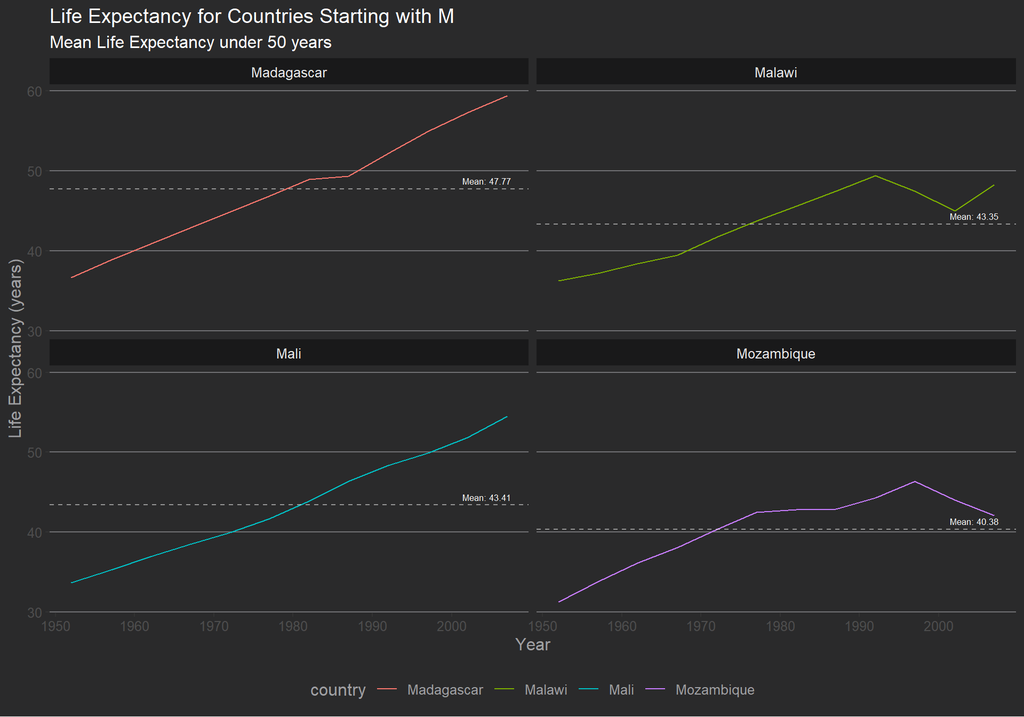

```r
# plot the life expectancy (using facet wrap)
gapminder %>%
    filter(country %in% m_countries$country) %>%
    ggplot(aes(x = year, y = lifeExp, color = country)) +
    geom_line() +
    # add mean life expectancy line
    geom_hline(
        data = m_countries,
        aes(yintercept = mean_life_expectancy),
        linetype = "dashed",
        color = "white",
        alpha = 0.5
    ) +
    # add mean life expectancy line label
    geom_text(
        data = m_countries,
        aes(
            x = year_max,
            y = mean_life_expectancy + 1,
            label = paste("Mean:", round(mean_life_expectancy, 2))
        ),
        nudge_x = -2.5,
        color = "white",
        size = 2.25
    ) +
    theme_hc(style = "darkunica") +
    theme(strip.background = element_rect(colour = "#00000000",
                                        fill = "#00000065"),
          strip.text = element_text(color = "#ececec")) +
    facet_wrap(~ country, ncol = 2) +
    labs(
        title = "Life Expectancy for Countries Starting with M",
        subtitle = "Mean Life Expectancy under 50 years",
        x = "Year",
        y = "Life Expectancy (years)"
    )
```